# 07 Plots

When we think about scatter plots, we usually think about regression lines. How about adding a line to the data, indicating how age and nerd score are associated with each other? The corresponding geom is called `geom_smooth`.

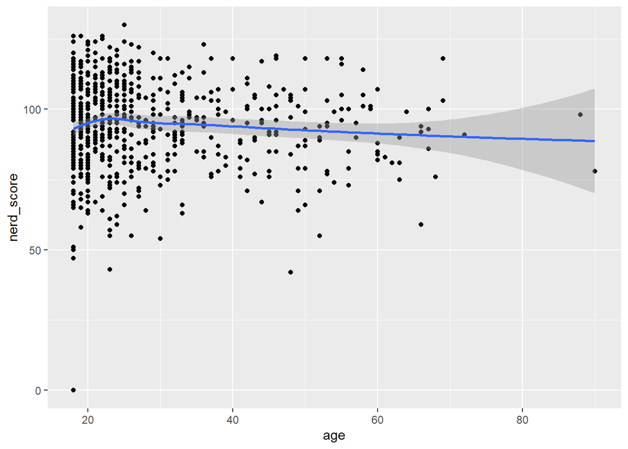

```r
nerd_red %>%
  ggplot(aes(x = age, y = nerd_score)) +
  geom_point() +
  geom_smooth()
```

The default method for `geom_smooth`, as `R` informs us, is “loess”. It “[fits] a polynomial surface determined by one or more numerical predictors, using local fitting.” (Run`?loess` in the console for more information.) You see that it does not produce a straight line - if we want a plain linear regression, we have to set the argument `method` to `"lm"`. With the argument `se = FALSE` we can get rid of the grey confidence interval around the data.

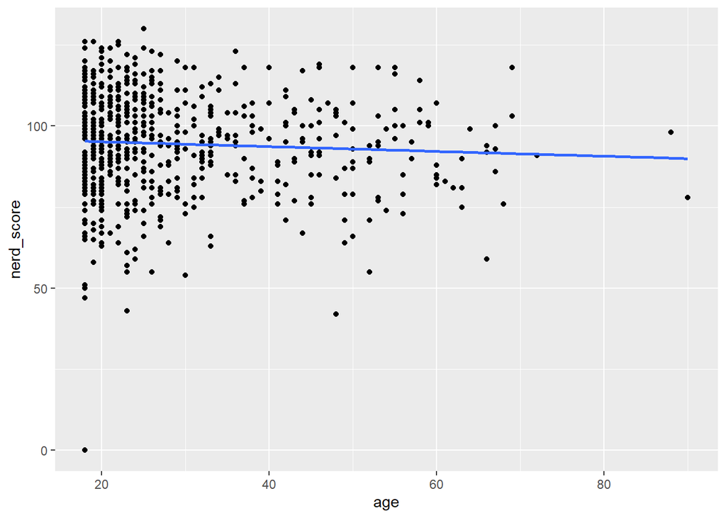

```r
nerd_red %>%
  ggplot(aes(x = age, y = nerd_score)) +
  geom_point() +
  geom_smooth(method = "lm", se = FALSE)
```

1.2) Use `geom_boxplot()` to plot participants’ marital status on the x axis, and the age on the y axis.

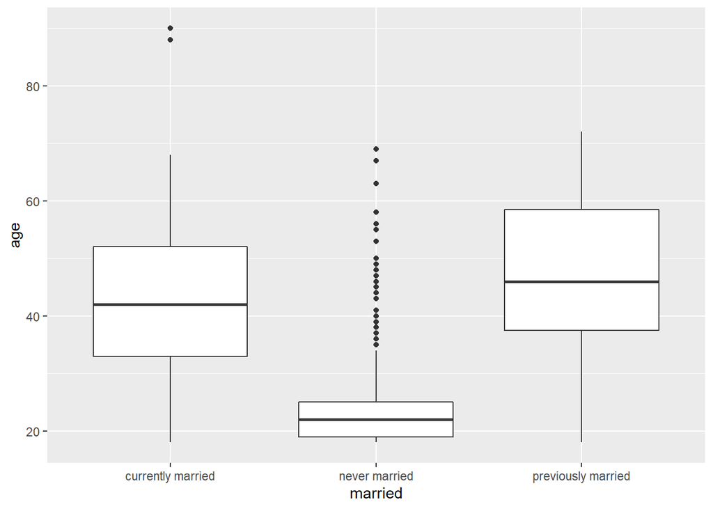

```r
nerd_red %>%
  ggplot(aes(x = married, y = age)) +
  geom_boxplot()
```

1.3) Create a scatter plot that displays the relationship between the `nerdy` question and the `nerd_score`.

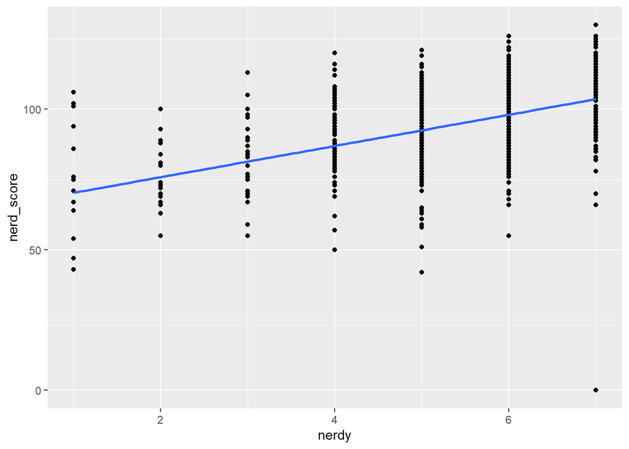

```r
nerd_red %>%
  ggplot(aes(x = nerdy, y = nerd_score)) +
  geom_point() +
  geom_smooth(method = "lm", se = FALSE)
```

## Building plots

It is worth pointing out that you can

1. save plots into variables just like anything else and
2. add layers to existing plots that are stored in variables.

For example, we could save the first layer of our plot in a variable:

```r
my_scatter_plot <-
  nerd_red %>%
  ggplot(aes(x = age, y = nerd_score))
```

… which we can then use to call the plot:

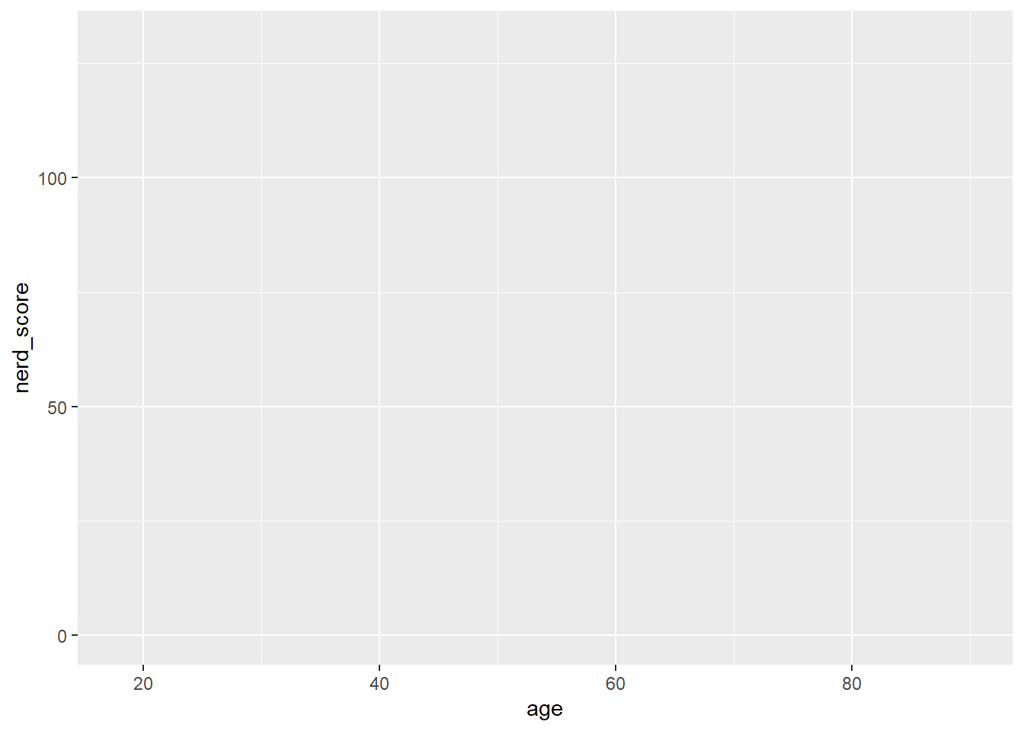

```r
my_scatter_plot
```

We can then simply add layers to the existing plot like this:

```r
my_scatter_plot +
  geom_point()
```

[output not shown]

This leaves the original plot intact. I didn’t overwrite `my_scatter_plot`, so it is unchanged:

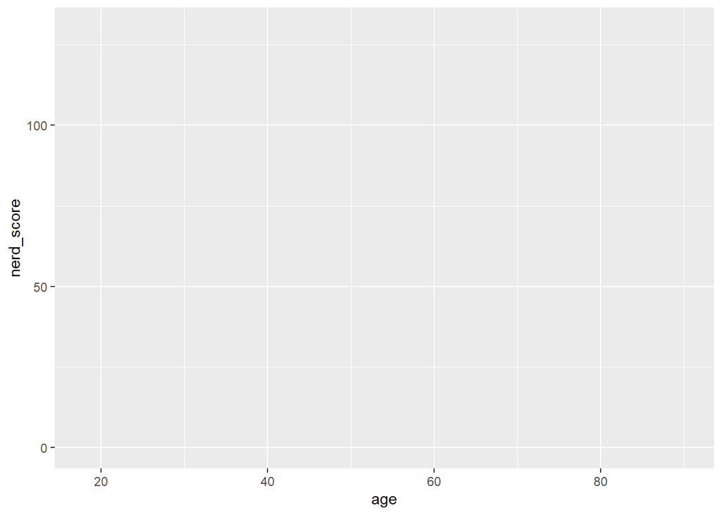

```r
my_scatter_plot
```

Building plots in separate steps like this can have advantages, for example when you want to have some structure in your code (e.g., first create your basic plot, and fine tune its appearance in a different step), or if you are building several similar plots with the same underlying structure. During this workshop, however, I will mostly avoid building plots like this. This has the advantage that whenever you see a plot, you will see the entire code that was used to create it. You won’t have to look for other layers that are “hidden” in different variables, which makes it easier to miss parts of a plot.

## Adding aesthetics

It is very easy to split our data into different subgroups in our plot. For example, we could examine what the relationship between age and nerd score looks like as a function of gender. We can use a different colour for each group in `gender` by using the `colour` argument inside of `aes()` (both `colour` and `color` will work).

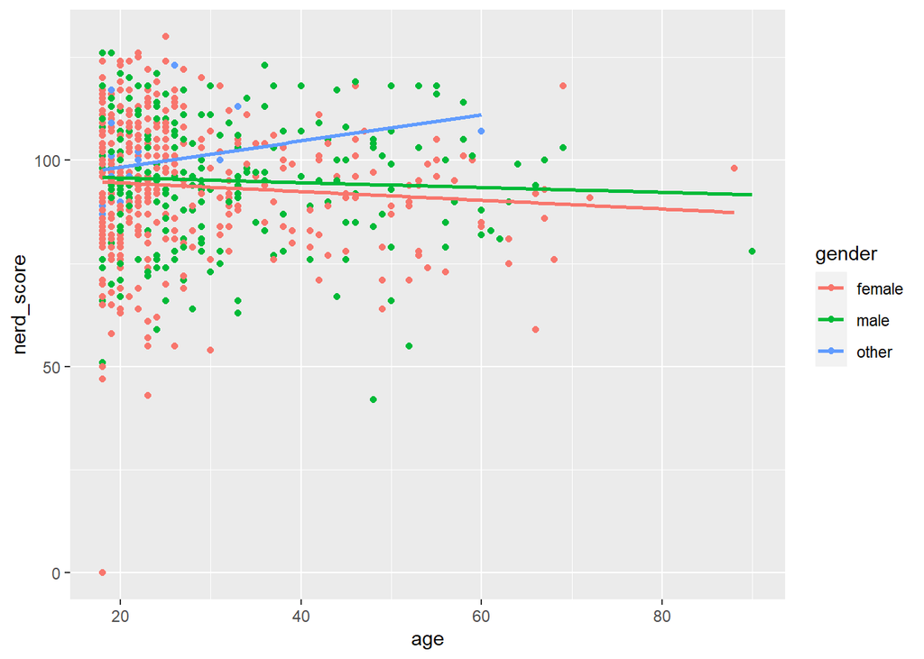

```r
nerd_red %>%
  ggplot(aes(x = age, y = nerd_score, colour = gender)) +
  geom_point() +
  geom_smooth(method = "lm", se = FALSE)
```

Note how `colour` worked on both `geom_point` and `geom_smooth`.

3.1) Create a more complex version of the plot from 1.2). Use `geom_boxplot()` to plot participants’ marital status on the x axis, and the age on the y axis. Colour the boxplots based on gender.

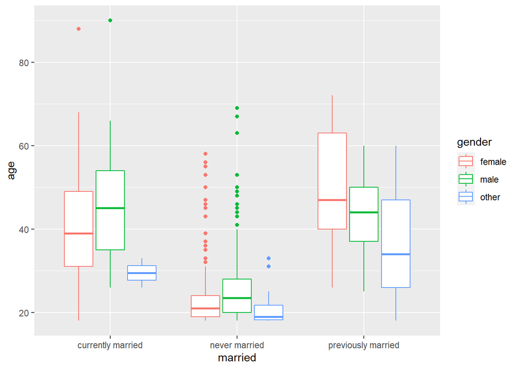

```r
nerd_red %>%
  ggplot(aes(x = married, y = age, colour = gender)) +
  geom_boxplot()
```

3.2) In the plot from 3.1), rename the argument `colour` to `fill`. What’s the difference?

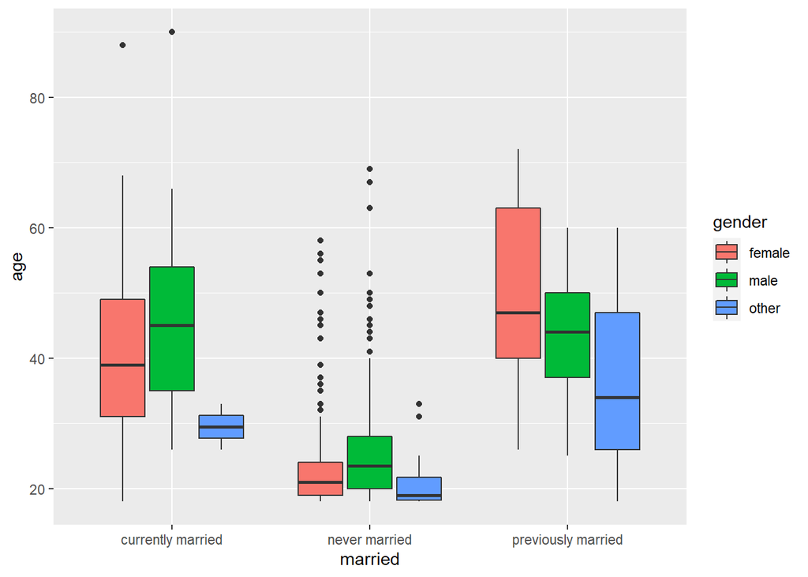

```r
nerd_red %>%
  ggplot(aes(x = married, y = age, fill = gender)) +
  geom_boxplot()
```

3.3) Create a scatter plot with `nerd_score` and `age`. Use the argument `shape` within `aes()` to group the data by marital status. Additionally, colour the data by marital status.

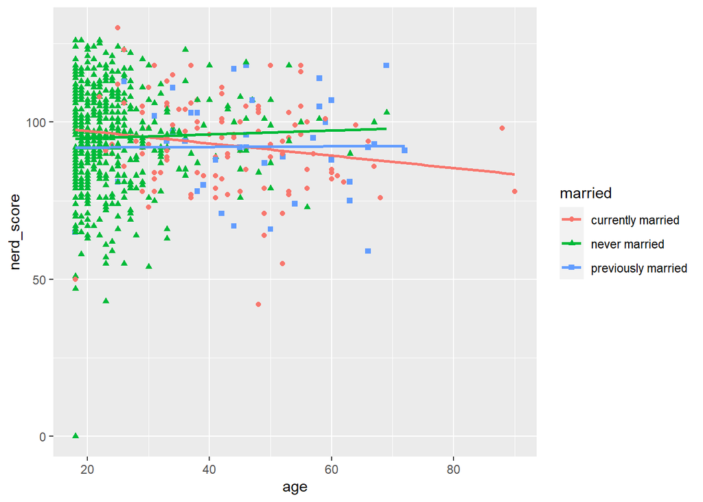

```r
nerd_red %>%
  ggplot(aes(x = age, y = nerd_score, shape= married, colour = married)) +
  geom_point() +
  geom_smooth(method = "lm", se = FALSE)
```

3.4) Create a scatter plot with `nerd_score` and `age`. Try using the argument `size = nerdy` within `aes()`. What happens if you use `colour` instead of size (or maybe even both)? Tip: It’s a bit easier to see what’s going on when you only use the first 50 rows or so of `nerd_red`.

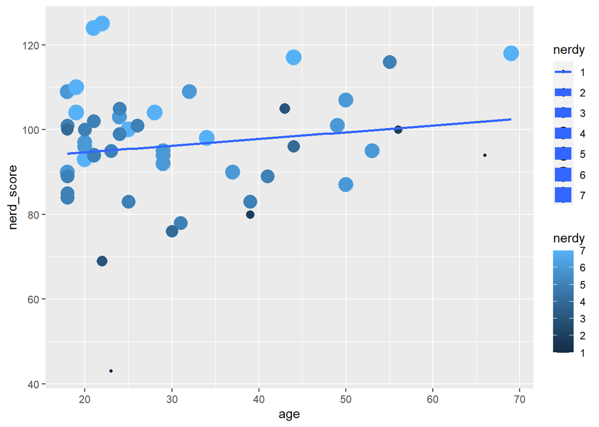

```r
nerd_red [1:50, ] %>%
  ggplot(aes(x = age, y = nerd_score , size= nerdy, colour = nerdy)) +
  geom_point() +
  geom_smooth(method = "lm", se = FALSE)
```

## Customise your plot

There are still a lot of things we can improve in the plots we created so far. For example, because `ggplot()` uses the column names it finds in the data, the y-axis in this plot is labelled with “nerd_score”.

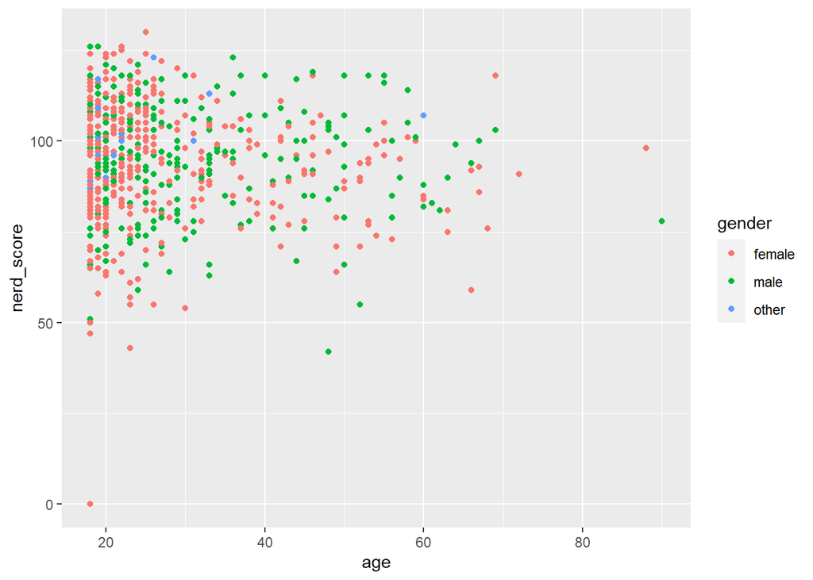

```r
nerd_red %>%
  ggplot(aes(x = age, y = nerd_score, colour = gender)) +
  geom_point()
```

We can change the axis label using the function `labs()`.

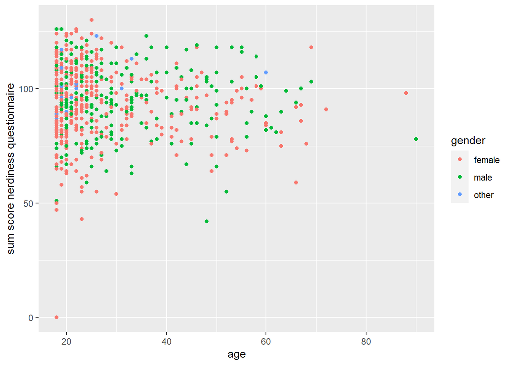

```r
nerd_red %>%
  ggplot(aes(x = age, y = nerd_score, colour = gender)) +
  geom_point() +
  labs(y = "sum score nerdiness questionnaire")
```

4.1) `labs()` can also change other labels of your plot. Run `?labs` and read the description of the function to find out which other labels it can change. Try all of them (except for `alt` and `alt_insight` - these only work for web-pages).

The legend would look better if it was at the top of our plot. In general, many things about our plot’s appearance can be controlled using the `theme()` function, such as like font sizes, what the grid lines and axes look like and much, much more.

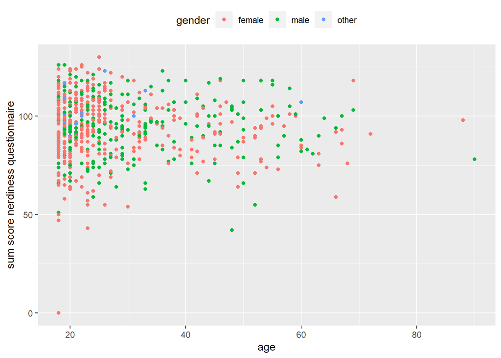

```r
nerd_red %>%
  ggplot(aes(x = age, y = nerd_score, colour = gender)) +
  geom_point() +
  labs(y = "sum score nerdiness questionnaire") +
  theme(legend.position = "top")
```

You can see all the different options of `theme()` by taking a look at `?theme`. Because there are so many things you can change, the options are a bit overwhelming. I normally prefer the [web version](https://ggplot2.tidyverse.org/reference/theme.html) of the documentation of `theme()`, because it’s easier to read.

Speaking of themes, the grey background with the white grid is the default theme `ggplot2` is very famous for. However, it is certainly not the most beautiful and modern plot appearance anymore. We could set up a custom theme by manually changing all the things we don’t like about the current theme using the `theme()` function, but we can also use a different pre-defined theme. You can find a list of themes [here](https://ggplot2.tidyverse.org/reference/ggtheme.html).

Adding one of these themes works like this:

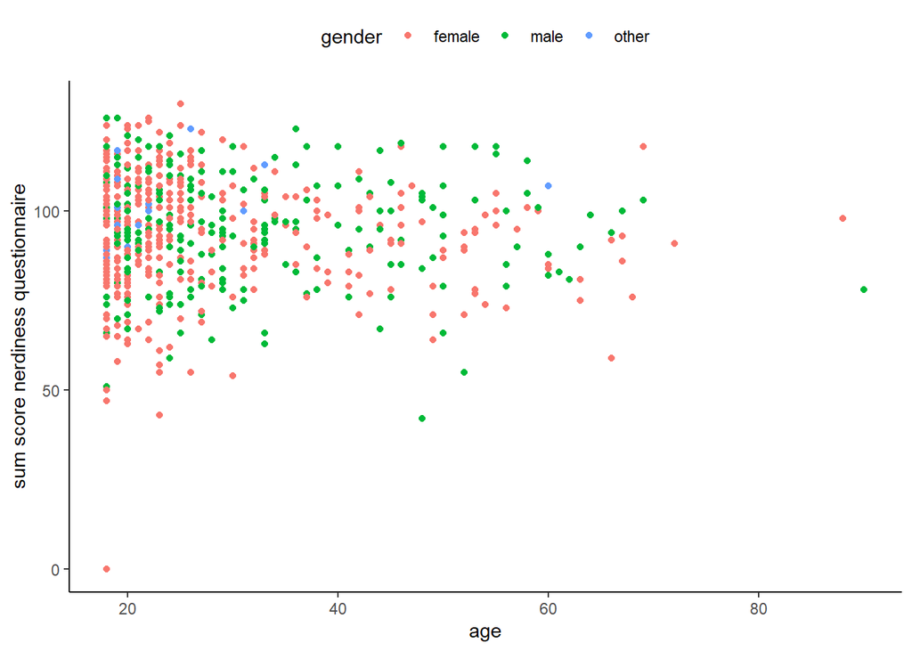

```r
nerd_red %>%
  ggplot(aes(x = age, y = nerd_score, colour = gender)) +
  geom_point() +
  labs(y = "sum score nerdiness questionnaire") +
  theme_classic() + # change theme
  theme(legend.position = "top")
```

Note that we have to put in `theme(legend.position = "top")` **after** `theme_classic()`. That is because `theme_classic()` has a predefined position for the legend (at the right side of the plot). If we use `theme_classic()` after `theme(legend.position = "top")`, it will overwrite the legend position we previously set:

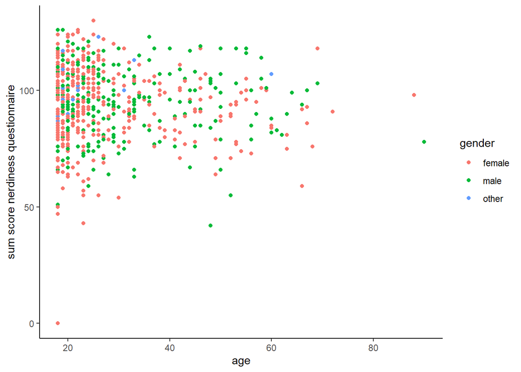

```r
nerd_red %>%
  ggplot(aes(x = age, y = nerd_score, colour = gender)) +
  geom_point() +
  labs(y = "sum score nerdiness questionnaire") +
  theme(legend.position = "top") + # is overwritten by the theme
  theme_classic() # overwrites the previous setting
```

4.2) Try a different theme!

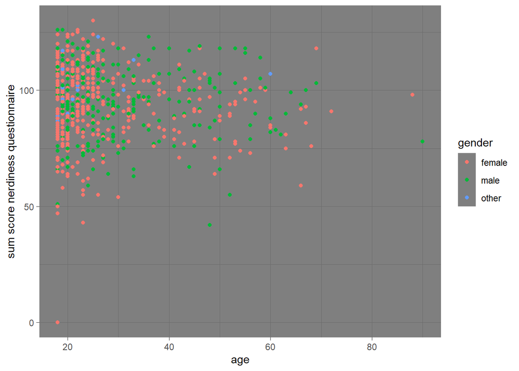

```r
nerd_red %>%
  ggplot(aes(x = age, y = nerd_score, colour = gender)) +
  geom_point() +
  labs(y = "sum score nerdiness questionnaire") +
  theme_dark()
```

Lastly, let’s change the steps on the x and y axis. For this task, the function `seq()` comes in handy, which generates a sequence of numbers. The arguments it takes are where the sequence begins, where it ends and how big the steps in between should be:

```r
# A sequence from 1 - 10 in steps of 2
seq(1, 10, 2)
```

```
## [1] 1 3 5 7 9
```

It is also possible not to give a step size, but the **number** of steps (i.e. the length of the output) instead:

```r
seq(1, 10, length.out = 6)
```

```
## [1]  1.0  2.8  4.6  6.4  8.2 10.0
```

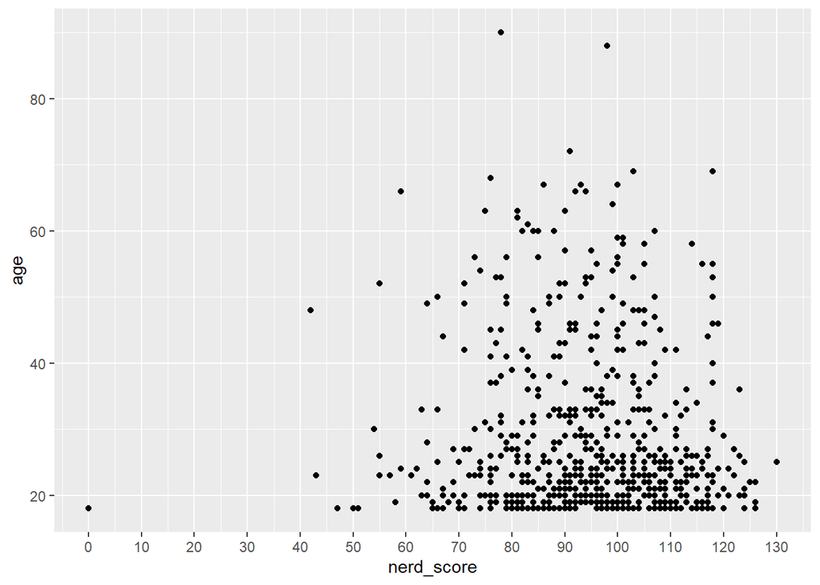

```r
nerd_red %>%
  ggplot(aes(x = nerd_score, y = age)) +
  geom_point() +
  scale_x_continuous(breaks = seq(0, 130, 10))
```

4.3) You can probably guess what the function for adjusting the y axis is called like. Use it to change the steps on the y-axis.

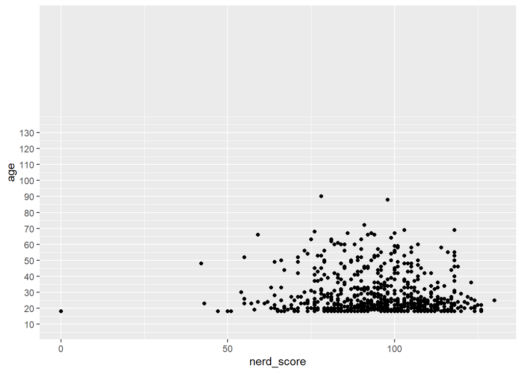

```r
nerd_red %>%
  ggplot(aes(x = nerd_score, y = age)) +
  geom_point() +
  scale_y_continuous(breaks = seq(0, 130, 10), limits = c(10, 200))
```

Note that the argument `breaks` only controls the size of the **steps** on an axis, but not the **limits**. In this example, we used breaks from 0 - 200, but the last label that is printed is 130.

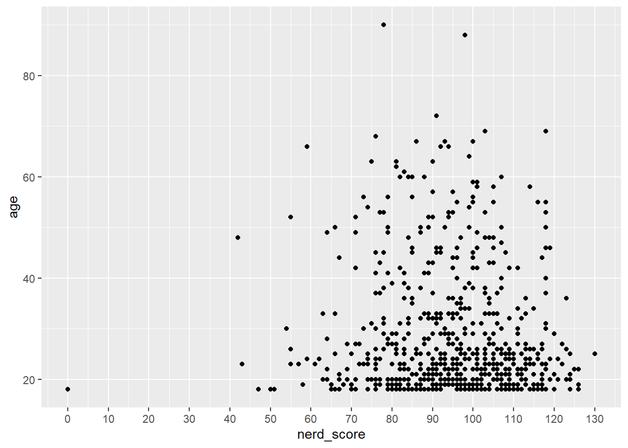

```r
nerd_red %>%
  ggplot(aes(x = nerd_score, y = age)) +
  geom_point() +
  scale_x_continuous(breaks = seq(0, 200, 10))
```

4.4) You can control the limits of an axis using the argument `limits` inside of `scale_x_continuous()`. It requires a vector with two elements as input: The first element controls the lower limit of the axis, the second element controls the upper limit of the axis. Try different limits for the x and y axis!

# Beyond aes()

So far, when we used different colours our shapes to plot our data, we did that inside of the `aes()` function. You might have wondered why we even need to wrap our code in an additional function. Here’s why: When we put something inside the `aes()` function, we are using the underlying data to control our plot’s appearance. When we use the same argument outside of `aes()`, we are controlling our plot’s appearance irrespective of the underlying data.

For example, here we colour the points in our scatter plot depending on our participants’ marital status.

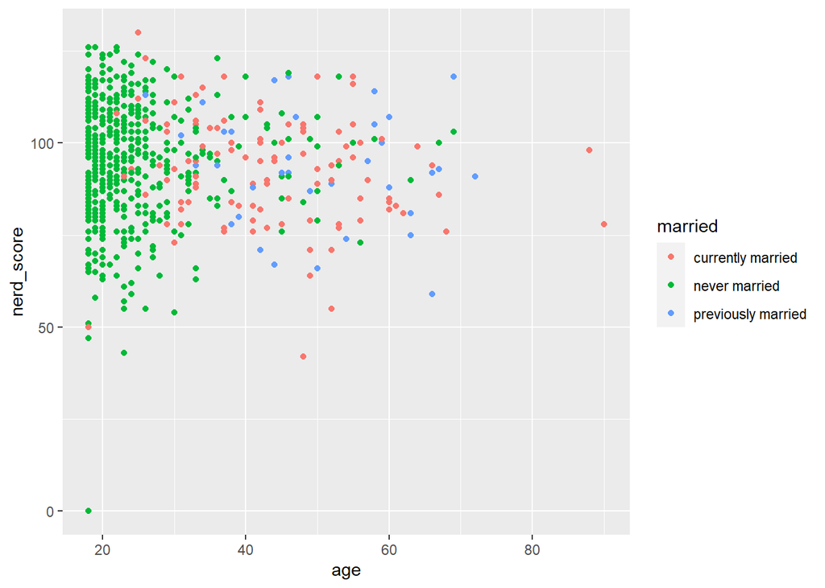

```r
nerd_red %>%
  ggplot(aes(x = age, y = nerd_score, colour = married)) +
  geom_point()
```

Used outside of `aes()`, the colour argument affects all data points.

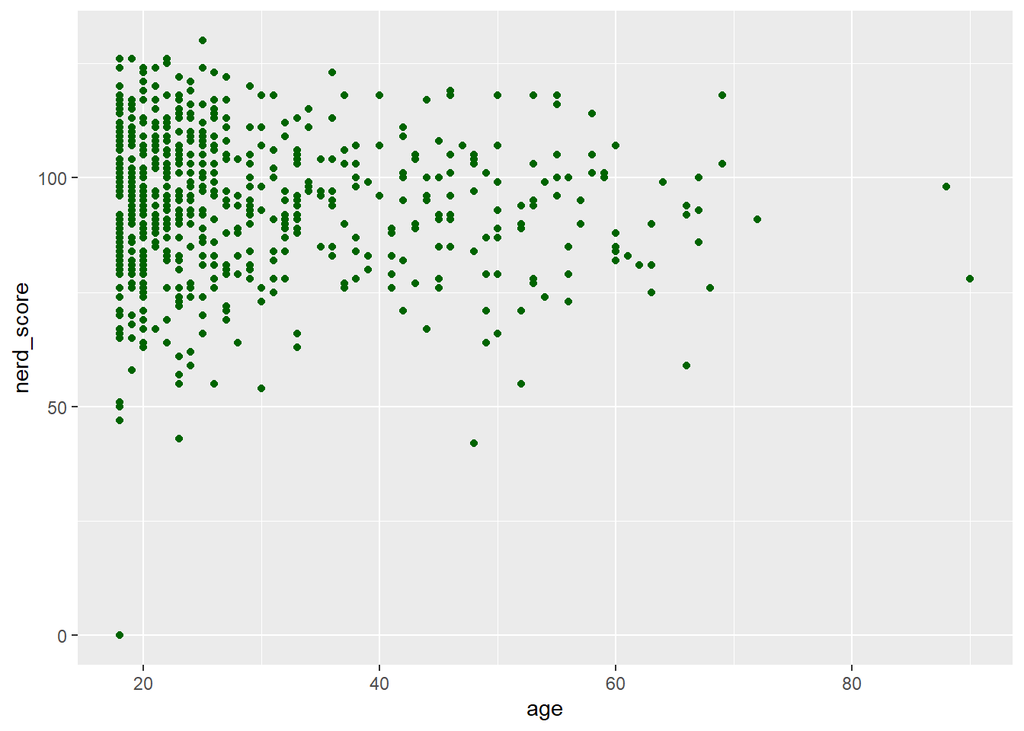

```r
nerd_red %>%
  ggplot(aes(x = age, y = nerd_score)) +
  geom_point(colour = "dark green")
```

We can refer to the colour that we want by name (i.e. `"black"`, or `"dark red"` - find a full list [here](http://www.stat.columbia.edu/~tzheng/files/Rcolor.pdf)), but can also use hex codes (e.g. `"#2d82b7"`).

Note that we have to use `colour` inside of `geom_point` - it won’t work in the `ggplot()` function:

```r
nerd_red %>%
  ggplot(aes(x = age, y = nerd_score), colour = "green") +
  geom_point()
```

[output not shown]

It helps to understand the difference between `colour` inside vs. outside of `aes()` if we use `colour = "green"` inside of `aes()`:

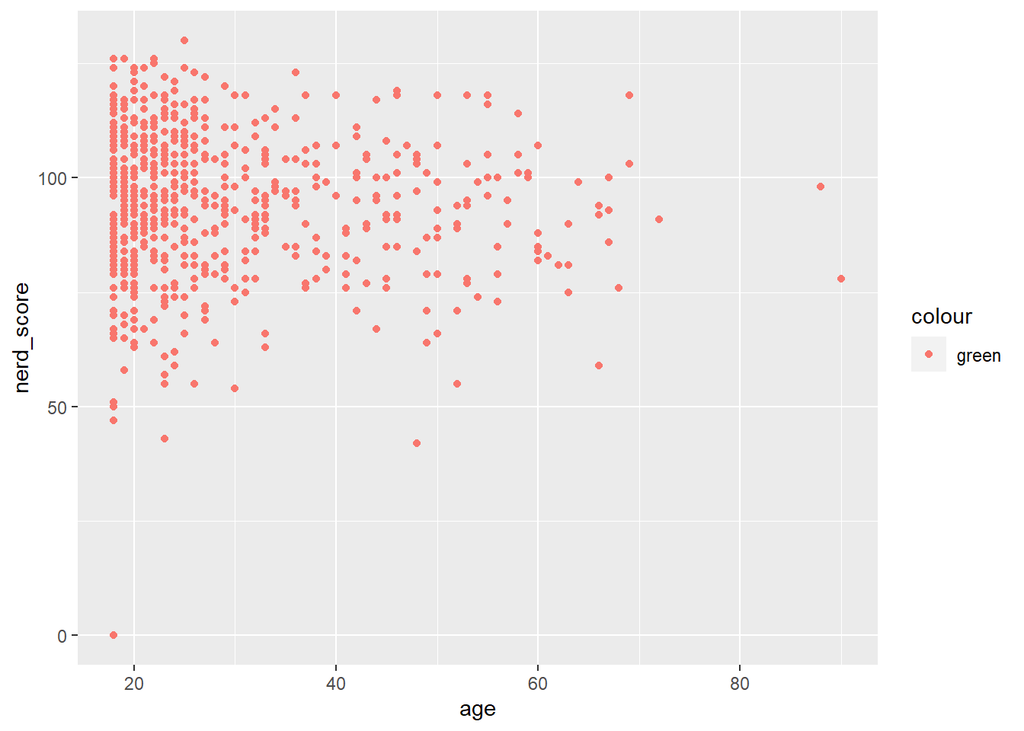

```r
nerd_red %>%
  ggplot(aes(x = age, y = nerd_score, colour = "green")) +
  geom_point()
```

4.5) Optional: Take a moment to think about what is going on here.

4.6) Try the arguments `size` and `alpha` outside of `aes()`. If you want to, you can use other geoms and try out how these arguments affect them.

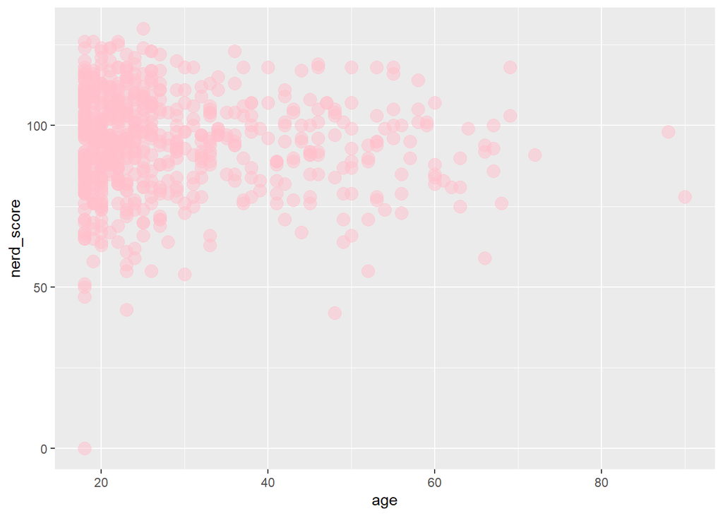

```r
nerd_red %>%
  ggplot(aes(x = age, y = nerd_score)) +
  geom_point(size=4, alpha =.5, colour= "pink")
```

## Custom colours

Outside of `aes()`, we can simply tell `R` which colours or shapes to use. But if we e.g. colour our data inside of `aes()`, we get default colours. Here’s how we change them:

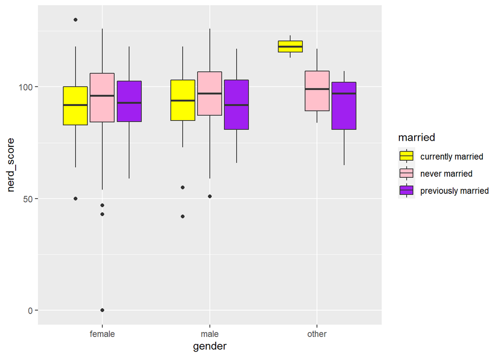

```r
nerd_red %>%
  ggplot(aes(x = gender, y = nerd_score, fill = married)) +
  scale_fill_manual(values = c("yellow", "pink", "purple")) + # custom colours
  geom_boxplot()
```

Using the `values` argument in `scale_fill_manual()`, we can provide `R` with a vector of custom colours we want to use in our plot. Note that we need to specify a value for each colour in the plot, i.e. if there are three different colours (groups) in the plot, we need to provide three colour values.

Changing other aesthetics works in the same way - the functions are just called slightly different. E.g. there’s `scale_colour_manual()` or `scale_shape_manual()`.

5.1) Create your own plot with custom aesthetics. Try out what happens if you change the order of the values in the vector.

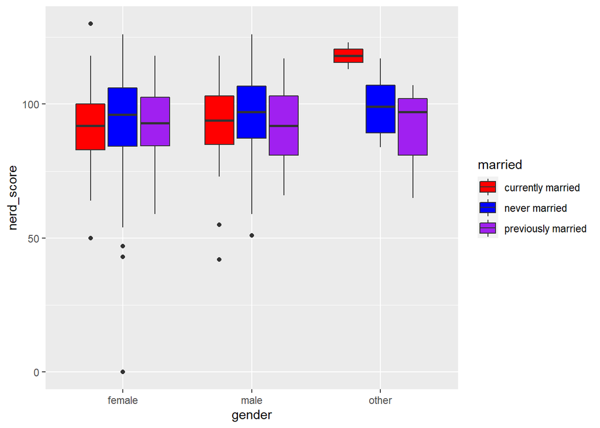

```r
nerd_red %>%
  ggplot(aes(x = gender, y = nerd_score, fill = married)) +
  scale_fill_manual(values = c("red", "blue", "purple")) + # custom colours
  scale_colour_manual(aesthetics = "orange", breaks = waiver(), na.value = "grey50")+
  geom_boxplot()
```